# Lecture 16: Difference-in-differences

Economics 326 — Introduction to Econometrics II

Vadim Marmer, UBC

## Motivation

- Previous lecture: treatment effects from **cross-sectional** data, assuming selection on observables (treatment is as good as random after controlling for covariates).
- Often hard to justify. Alternative: exploit data over time:
  - **Panel data**: repeated observations on the exact same units over time.
  - **Repeated cross-sections**: observations on different units from the same populations at different points in time.
- **Difference-in-differences (DID)**: compare changes over time between a treatment group and a control group.

## DID basic setup

- Two time periods: $t \in \{0, 1\}$ (before and after treatment).
- Two groups: $D_i \in \{0, 1\}$ (control and treatment).
- Treatment occurs between periods 0 and 1; only the treatment group ($D_i = 1$) is affected.
- $Y_{it}$: outcome for individual $i$ at time $t$.

## DID regression model

- DID regression:

  $$Y_{it} = \alpha + {\color{blue}\delta} \cdot t + {\color{purple}\gamma} D_i + {\color{teal}\beta}(t \cdot D_i) + U_{it},$$

  where $\mathrm{E}\left[U_{it} \mid D_i\right] = 0$.
- Regressors:
  - $t$: time (0 = before, 1 = after).
  - $D_i$: group (0 = control, 1 = treatment).
  - $t \cdot D_i$: interaction, equals 1 only for the treatment group after treatment.

## Interpreting the coefficients

- $$Y_{it} = \alpha + {\color{blue}\delta} \cdot t + {\color{purple}\gamma} D_i + {\color{teal}\beta}(t \cdot D_i) + U_{it},$$
- Evaluate $\mathrm{E}\left[Y_{it} \mid D_i\right]$ for each combination of $t$ and $D_i$:

  $$\begin{align*}
  t = 0,\ D_i = 0: \quad & \mathrm{E}\left[Y_{i0} \mid D_i = 0\right] = \alpha, \\
  t = 0,\ D_i = 1: \quad & \mathrm{E}\left[Y_{i0} \mid D_i = 1\right] = \alpha + {\color{purple}\gamma}, \\
  t = 1,\ D_i = 0: \quad & \mathrm{E}\left[Y_{i1} \mid D_i = 0\right] = \alpha + {\color{blue}\delta}, \\
  t = 1,\ D_i = 1: \quad & \mathrm{E}\left[Y_{i1} \mid D_i = 1\right] = \alpha + {\color{blue}\delta} + {\color{purple}\gamma} + {\color{teal}\beta}.
  \end{align*}$$
- Summarized as a 2×2 table:

  |  | $D_i = 0$ (Control) | $D_i = 1$ (Treatment) |
  | --- | --- | --- |
  | $t = 0$ | $\alpha$ | $\alpha + {\color{purple}\gamma}$ |
  | $t = 1$ | $\alpha + {\color{blue}\delta}$ | $\alpha + {\color{blue}\delta} + {\color{purple}\gamma} + {\color{teal}\beta}$ |

- $\alpha$: baseline (control group, $t = 0$).
- ${\color{purple}\gamma}$: pre-existing **group difference** at $t = 0$.
- ${\color{blue}\delta}$: **time effect** — change in the control group from $t = 0$ to $t = 1$ (common trend).
- Change over time for each group:
  - **Treatment:** $\mathrm{E}\left[Y_{i{\color{red}1}} \mid D_i = 1\right] - \mathrm{E}\left[Y_{i{\color{red}0}} \mid D_i = 1\right] = {\color{blue}\delta} + {\color{teal}\beta}$.
  - **Control:** $\mathrm{E}\left[Y_{i{\color{red}1}} \mid D_i = 0\right] - \mathrm{E}\left[Y_{i{\color{red}0}} \mid D_i = 0\right] = {\color{blue}\delta}$.
- Subtract control’s change from treatment’s change:

  $$({\color{blue}\delta} + {\color{teal}\beta}) - {\color{blue}\delta} = {\color{teal}\beta}.$$
- DID estimand as a double difference:

  $$\begin{align*}
  {\color{teal}\beta} &= \mathrm{E}\left[Y_{i1} - Y_{i0} \mid D_i = 1\right] - \mathrm{E}\left[Y_{i1} - Y_{i0} \mid D_i = 0\right].
  \end{align*}$$
- The common trend ${\color{blue}\delta}$ cancels, isolating ${\color{teal}\beta}$.

## DID diagram

- DID regression: $Y_{it} = \alpha + {\color{blue}\delta} \cdot t + {\color{purple}\gamma} D_i + {\color{teal}\beta}(t \cdot D_i) + U_{it}$.
- DID diagram — control, treatment, and counterfactual:

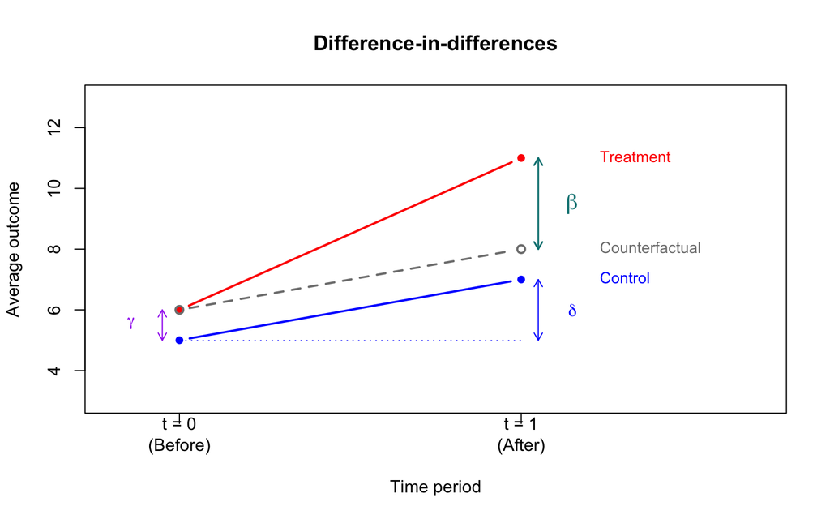

- Counterfactual (dashed gray): treatment group’s baseline $\alpha + {\color{purple}\gamma}$ plus the control group’s change ${\color{blue}\delta}$.

## DID and potential outcomes

- **Panel potential outcomes**: $Y_{it}(d)$ — outcome for individual $i$ at time $t$ if assigned to group $d \in \{0, 1\}$.
- Four potential outcomes: $Y_{i0}(0)$, $Y_{i1}(0)$, $Y_{i0}(1)$, $Y_{i1}(1)$.
- The observed outcome is:

  $$Y_{it} = D_i \, Y_{it}(1) + (1 - D_i) \, Y_{it}(0).$$
- What we observe for each group:

  |  | Control ($D_i = 0$) | Treatment ($D_i = 1$) |
  | --- | --- | --- |
  | $t = 0$ | $Y_{i0}(0)$ | $Y_{i0}(1)$ |
  | $t = 1$ | $Y_{i1}(0)$ | $Y_{i1}(1)$ |

- Treatment effect on the treated at $t = 1$:

  $${\color{teal}\text{ATT}} = {\color{teal}\mathrm{E}\left[Y_{i1}(1) - Y_{i1}(0) \mid D_i = 1\right]}.$$

  The counterfactual $Y_{i1}(0)$ is unobserved for the treated group.

## DID as a treatment effect

- ${\color{teal}\beta} = \mathrm{E}\left[Y_{i1} - Y_{i0} \mid D_i = 1\right] - \mathrm{E}\left[Y_{i1} - Y_{i0} \mid D_i = 0\right]$.
- Substituting observed outcomes with potential outcomes:

  $$\begin{align*}
  \beta &= \mathrm{E}\left[{\color{teal}Y_{i1}(1)} {\color{red}- Y_{i0}(1)} \mid D_i = 1\right] \\
  &\quad {\color{blue}- \mathrm{E}\left[Y_{i1}(0) - Y_{i0}(0) \mid D_i = 0\right]}.
  \end{align*}$$
- To relate $\beta$ to the ATT, add and subtract $Y_{i1}(0)$ and $Y_{i0}(0)$ inside the first expectation:

  $$\begin{align*}
  \beta &= \mathrm{E}\left[{\color{teal}Y_{i1}(1)} {\color{red}- Y_{i0}(1)} \mid D_i = 1\right] {\color{blue}- \mathrm{E}\left[Y_{i1}(0) - Y_{i0}(0) \mid D_i = 0\right]} \\
  &= \mathrm{E}\left[{\color{teal}Y_{i1}(1)} \underbrace{{\color{teal}- Y_{i1}(0)} {\color{blue}+ Y_{i1}(0)}}_{= \, 0} \underbrace{{\color{blue}- Y_{i0}(0)} {\color{red}+ Y_{i0}(0)}}_{= \, 0} {\color{red}- Y_{i0}(1)} \mid D_i = 1\right] \\
  &\quad {\color{blue}- \mathrm{E}\left[Y_{i1}(0) - Y_{i0}(0) \mid D_i = 0\right]}.
  \end{align*}$$
- Rearranging and splitting the expectation:

  $$\begin{align*}
  \beta &= \underbrace{{\color{teal}\mathrm{E}\left[Y_{i1}(1) - Y_{i1}(0) \mid D_i = 1\right]}}_{\color{teal}\text{ATT}} \\
  &\quad + \underbrace{{\color{blue}\mathrm{E}\left[Y_{i1}(0) - Y_{i0}(0) \mid D_i = 1\right] - \mathrm{E}\left[Y_{i1}(0) - Y_{i0}(0) \mid D_i = 0\right]}}_{\color{blue}\text{difference in trends}} \\
  &\quad + \underbrace{{\color{red}\mathrm{E}\left[Y_{i0}(0) - Y_{i0}(1) \mid D_i = 1\right]}}_{\color{red}\text{anticipation effect}}.
  \end{align*}$$
- For ${\color{teal}\beta}$ to equal the ${\color{teal}\text{ATT}}$, the ${\color{blue}\text{difference in trends}}$ and ${\color{red}\text{anticipation effect}}$ must be zero. This requires two assumptions.

## Assumption 1: Parallel trends

- Difference in trends is zero if both groups would have experienced the same change over time absent treatment:

  $${\color{blue}\mathrm{E}\left[Y_{i{\color{red}1}}(0) - Y_{i{\color{red}0}}(0) \mid D_i = 1\right] = \mathrm{E}\left[Y_{i{\color{red}1}}(0) - Y_{i{\color{red}0}}(0) \mid D_i = 0\right]}.$$
- Under parallel trends, the decomposition reduces to:

  $${\color{teal}\beta} = {\color{teal}\text{ATT}} + \underbrace{{\color{red}\mathrm{E}\left[Y_{i0}(0) - Y_{i0}(1) \mid D_i = 1\right]}}_{\color{red}\text{anticipation effect}}.$$
- Cannot be directly tested: $Y_{i1}(0)$ is unobserved for the treated group.
- With multiple pre-treatment periods, can check whether trends were parallel before treatment.

## Assumption 2: No anticipation

- Anticipation effect is zero if pre-treatment outcomes are not affected by future treatment assignment:

  $$\mathrm{E}\left[Y_{i{\color{red}0}}(1) \mid D_i = 1\right] = \mathrm{E}\left[Y_{i{\color{red}0}}(0) \mid D_i = 1\right].$$
- Treatment assignment does not change pre-treatment outcomes in expectation.
- Under both parallel trends and no anticipation:

  $${\color{teal}\beta} = {\color{teal}\text{ATT}}.$$

## Example: incinerator and house prices

- Kiel and McClain (1995): did a garbage incinerator in North Andover, MA reduce nearby house prices?
- This is a **repeated cross-section**: the houses sold in 1981 (after) are different from the houses sold in 1978 (before).
- Data: `kielmc` from the `wooldridge` package:

  ```r
  library(wooldridge)
  data(kielmc)
  # Show 2 observations from each of the 4 groups
  rows <- c(
    head(which(kielmc$y81 == 0 & kielmc$nearinc == 0), 2),
    head(which(kielmc$y81 == 0 & kielmc$nearinc == 1), 2),
    head(which(kielmc$y81 == 1 & kielmc$nearinc == 0), 2),
    head(which(kielmc$y81 == 1 & kielmc$nearinc == 1), 2)
  )
  kielmc[rows, c("rprice", "y81", "nearinc", "age")]
  ```

  ```
        rprice y81 nearinc age
  14  52000.00   0       0  32
  15  49000.00   0       0  18
  1   60000.00   0       1  48
  2   40000.00   0       1  83
  187 90245.77   1       0   1
  188 46082.95   1       0  41
  180 37634.41   1       1  81
  181 39938.55   1       1  71
  ```

- `rprice`: house price in 1978 dollars ($Y_{it}$).
- `y81`: 1 if year is 1981 (after incinerator announced), 0 if 1978 ($t = 1$ if 1981, 0 if 1978).
- `nearinc`: 1 if house is near the incinerator site ($D_i$).

## The 2×2 table of means

- Compute the four group means:

  ```r
  means <- tapply(kielmc$rprice, list(kielmc$y81, kielmc$nearinc), mean)
  colnames(means) <- c("Far (nearinc=0)", "Near (nearinc=1)")
  rownames(means) <- c("1978 (y81=0)", "1981 (y81=1)")
  round(means, 2)
  ```

  ```
               Far (nearinc=0) Near (nearinc=1)
  1978 (y81=0)        82517.23         63692.86
  1981 (y81=1)       101307.51         70619.24
  ```

- Computing the DID by hand:

  ```r
  diff_near <- means[2, 2] - means[1, 2]
  diff_far  <- means[2, 1] - means[1, 1]
  DID <- diff_near - diff_far
  cat("Change (near):", round(diff_near, 2), "\n")
  ```

  ```
  Change (near): 6926.38
  ```

  ```r
  cat("Change (far): ", round(diff_far, 2), "\n")
  ```

  ```
  Change (far):  18790.29
  ```

  ```r
  cat("DID:          ", round(DID, 2), "\n")
  ```

  ```
  DID:           -11863.9
  ```

## DID regression

- The DID regression, where `y81nrinc` $= \text{y81} \times \text{nearinc}$ is the interaction term:

  ```r
  options(scipen = 999)
  reg_did <- lm(rprice ~ y81 + nearinc + y81nrinc, data = kielmc)
  round(summary(reg_did)$coefficients, 4)
  ```

  ```
               Estimate Std. Error t value Pr(>|t|)
  (Intercept)  82517.23   2726.910 30.2603   0.0000
  y81          18790.29   4050.065  4.6395   0.0000
  nearinc     -18824.37   4875.322 -3.8612   0.0001
  y81nrinc    -11863.90   7456.646 -1.5911   0.1126
  ```

- Coefficient on `y81nrinc` matches the DID from the 2×2 table.
- $\hat{\beta} = -\$11{,}864$ (SE $= 7{,}457$, $p = 0.113$): negative but not significant at 5%.

## Assumptions in the incinerator example

- **Parallel trends:** without the incinerator, house prices near and far from the site would have followed the same trend over time.
- **No anticipation:** before the incinerator was announced, living near the future site did not affect house prices.

## Why add covariates? Compositional changes

- Because this is a **repeated cross-section**, the houses sold in 1981 are different from those sold in 1978.
- What if the *mix* of houses sold changed over time? Look at the average age of houses sold:

  ```r
  means_age <- tapply(kielmc$age, list(kielmc$y81, kielmc$nearinc), mean)
  colnames(means_age) <- c("Far (nearinc=0)", "Near (nearinc=1)")
  rownames(means_age) <- c("1978 (y81=0)", "1981 (y81=1)")
  round(means_age, 2)
  ```

  ```
               Far (nearinc=0) Near (nearinc=1)
  1978 (y81=0)           12.75            39.79
  1981 (y81=1)            8.50            27.95
  ```

- **Compositional change**: In the “Far” group, houses sold in 1981 were 4.25 years newer than in 1978. But in the “Near” group, they were **11.84 years newer**.
- The “Near” group got disproportionately newer. Since newer houses generally sell for more, this drastic change in composition artificially pushes the “Near” average prices up.
- This artificial price bump from the change in age composition partially **masked** the negative effect of the incinerator in our simple DID regression.

## DID regression with covariates

- To remove this bias, we must control for age. This adjusts for the fact that the two groups experienced different compositional changes over time.

  ```r
  reg_did_cov <- lm(rprice ~ y81 + nearinc + y81nrinc + age + I(age^2),
                     data = kielmc)
  round(summary(reg_did_cov)$coefficients, 4)
  ```

  ```
                 Estimate Std. Error  t value Pr(>|t|)
  (Intercept)  89116.5354  2406.0511  37.0385   0.0000
  y81          21321.0418  3443.6311   6.1914   0.0000
  nearinc       9397.9359  4812.2218   1.9529   0.0517
  y81nrinc    -21920.2700  6359.7454  -3.4467   0.0006
  age          -1494.4240   131.8603 -11.3334   0.0000
  I(age^2)         8.6913     0.8481  10.2476   0.0000
  ```

- With age controls: $\hat{\beta} = -\$21{,}920$ (SE $= 6{,}360$, $p = 0.0006$) — nearly twice as large, highly significant.
- Estimated bias from compositional change: $-\$11{,}864 - (-\$21{,}920) \approx +\$10{,}056$. The simple DID was severely biased upward because the “Near” houses sold in 1981 were unusually new.

## Detecting anticipation and pre-trends

- With only two time periods, anticipation effects **cannot** be separately identified.
- With **multiple pre-treatment periods**, use an **event study** design. Data span $t = -T, \ldots, -1, 0, 1, \ldots, T'$, where ${\color{red}t = 0}$ **is now the treatment date** (not “before” as in the two-period model).
- Replace the single interaction $\beta(t \cdot D_i)$ with a separate coefficient per period. The baseline is $t = -1$ (last pre-treatment period):

  $$\begin{align*}
  Y_{it} &= \alpha + \sum_{s \neq -1} {\color{blue}\delta_s} \cdot \mathbb{1}[t = s] + {\color{purple}\gamma} D_i \\
  &\quad + \sum_{s \neq -1} {\color{teal}\beta_s} \cdot D_i \cdot \mathbb{1}[t = s] + U_{it}.
  \end{align*}$$
- Expected outcomes for $t = -2$ and $t = -1$:

  |  | $D_i = 0$ (Control) | $D_i = 1$ (Treatment) |
  | --- | --- | --- |
  | $t = -1$ | $\alpha$ | $\alpha + {\color{purple}\gamma}$ |
  | $t = -2$ | $\alpha + {\color{blue}\delta_{-2}}$ | $\alpha + {\color{blue}\delta_{-2}} + {\color{purple}\gamma} + {\color{teal}\beta_{-2}}$ |
  | Backward trend ($t\!:\! -1 \to -2$) | ${\color{blue}\delta_{-2}}$ | ${\color{blue}\delta_{-2}} + {\color{teal}\beta_{-2}}$ |

- ${\color{teal}\beta_{-2}}$ is the difference in backward trends from $t = -1$ to $t = -2$ between treatment and control: $({\color{blue}\delta_{-2}} + {\color{teal}\beta_{-2}}) - {\color{blue}\delta_{-2}} = {\color{teal}\beta_{-2}}$.
- More generally, ${\color{teal}\beta_s}$ for $s \leq -2$ is the difference in backward trends from $t = -1$ to $t = s$ between treatment and control.
- No anticipation + parallel pre-trends $\implies$ ${\color{teal}\beta_s} = 0$ for all $s \leq -2$. However, we never observe $Y_{it}(0)$ for the treated group, so nonzero ${\color{teal}\beta_s}$ tests the **joint** hypothesis: we cannot determine which assumption failed.
- The critical point: with multiple pre-treatment periods, we can **compare the two groups before treatment**. Since ${\color{teal}\beta_s}$ for $s \leq -2$ are estimable from pre-treatment data, ${\color{teal}\beta_s} = 0$ is a **testable** implication of the joint hypothesis.
- ${\color{teal}\beta_s}$ all equal and nonzero **suggests anticipation** at $t = -1$: backward trends are the same for all $s \leq -2$, but something shifts at the baseline period.
- ${\color{teal}\beta_s}$ nonzero and unequal **suggests a parallel trends violation**: groups were already diverging before treatment.
- For $s \geq 0$: under parallel trends and no anticipation, ${\color{teal}\beta_s}$ measures the **treatment effect** at period $s$ relative to $t = -1$.

## Time fixed effects

- In the two-period model, the term ${\color{blue}\delta} \cdot t$ creates two intercepts: $\alpha$ at $t = 0$ and $\alpha + {\color{blue}\delta}$ at $t = 1$.
- With multiple periods $t = -T, \ldots, -1, 0, 1, \ldots, T'$, we cannot use ${\color{blue}\delta} \cdot t$ because that forces a **linear** trend: the time effect at period $s$ would be $\delta \cdot s$, with no flexibility.
- Instead, include a separate dummy for each period. The regression actually estimated is:

  $$\begin{align*}
  Y_{it} &= \alpha + \cdots + {\color{blue}\delta_{-2}} \cdot \mathbb{1}[t = -2] + {\color{blue}\delta_0} \cdot \mathbb{1}[t = 0] + {\color{blue}\delta_1} \cdot \mathbb{1}[t = 1] + \cdots \\
  &\quad + {\color{purple}\gamma} D_i + \cdots + U_{it}.
  \end{align*}$$
- The key property: $\mathbb{1}[t = s]$ equals $1$ when $t = s$ and $0$ otherwise. At $t = -1$ all dummies are zero (baseline). At any other $t$, exactly one dummy equals $1$:

  | Period | Active dummy | Intercept |
  | --- | --- | --- |
  | $t = -1$ | none (baseline) | $\alpha$ |
  | $t = 0$ | $\mathbb{1}[t = 0] = 1$ | $\alpha + {\color{blue}\delta_0}$ |
  | $t = 1$ | $\mathbb{1}[t = 1] = 1$ | $\alpha + {\color{blue}\delta_1}$ |

- Each period gets its own intercept. The compact notation $\sum_{s \neq -1} {\color{blue}\delta_s} \cdot \mathbb{1}[t = s]$ writes the time dummies as a sum. The event study model with all the dummies written out:

  $$\begin{align*}
  Y_{it} &= \alpha + \cdots + {\color{blue}\delta_{-2}} \mathbb{1}[t\!=\!-2] + {\color{blue}\delta_0} \mathbb{1}[t\!=\!0] + {\color{blue}\delta_1} \mathbb{1}[t\!=\!1] + \cdots \\
  &\quad + {\color{purple}\gamma} D_i + \cdots + {\color{teal}\beta_{-2}} D_i \mathbb{1}[t\!=\!-2] + {\color{teal}\beta_0} D_i \mathbb{1}[t\!=\!0] + {\color{teal}\beta_1} D_i \mathbb{1}[t\!=\!1] + \cdots + U_{it}.
  \end{align*}$$
- At each $t$, exactly one time dummy survives (and at $t = -1$ none do). So $\alpha + {\color{blue}\delta_t}$ is the intercept at time $t$. Define ${\color{blue}\lambda_t} = \alpha + {\color{blue}\delta_t}$ (with $\delta_{-1} = 0$):

  $$\ldots, \quad {\color{blue}\lambda_{-1}} = \alpha, \quad {\color{blue}\lambda_0} = \alpha + {\color{blue}\delta_0}, \quad {\color{blue}\lambda_1} = \alpha + {\color{blue}\delta_1}, \quad \ldots$$

  The ${\color{blue}\lambda_t}$’s are called **time fixed effects**. This is the regression we actually run in OLS, with a dummy for each period:

  $$\begin{align*}
  Y_{it} &= \cdots + {\color{blue}\lambda_{-1}} \mathbb{1}[t\!=\!-1] + {\color{blue}\lambda_0} \mathbb{1}[t\!=\!0] + {\color{blue}\lambda_1} \mathbb{1}[t\!=\!1] + \cdots \\
  &\quad + {\color{purple}\gamma} D_i + \cdots + {\color{teal}\beta_{-2}} D_i \mathbb{1}[t\!=\!-2] + {\color{teal}\beta_0} D_i \mathbb{1}[t\!=\!0] + {\color{teal}\beta_1} D_i \mathbb{1}[t\!=\!1] + \cdots + U_{it}.
  \end{align*}$$
- At each $t$, exactly one $\lambda$-dummy equals $1$ and all others are zero:

  $$\underbrace{\cdots + {\color{blue}\lambda_t} \cdot 1 + \cdots}_{\text{only } {\color{blue}\lambda_t} \text{ survives}} = {\color{blue}\lambda_t}.$$

  The notation ${\color{blue}\lambda_t}$ is shorthand for this — it represents whichever $\lambda$ is active at time $t$:

  $$Y_{it} = {\color{blue}\lambda_t} + {\color{purple}\gamma} D_i + \sum_{s \neq -1} {\color{teal}\beta_s} \cdot D_i \cdot \mathbb{1}[t = s] + U_{it}.$$

## Individual fixed effects

- **Note**: The following requires **panel data** (observing the exact same individuals over time). It cannot be used with repeated cross-sections like the incinerator example.
- The same idea can be applied to individuals. In the event study model, the intercept for individual $i$ is $\alpha + {\color{purple}\gamma} D_i$. This allows only **two** values:

  | Group | Intercept |
  | --- | --- |
  | Control ($D_i = 0$) | $\alpha$ |
  | Treatment ($D_i = 1$) | $\alpha + {\color{purple}\gamma}$ |

  All individuals within the same group share the same baseline. But individuals may differ even within a group (e.g., houses near the incinerator differ in size, age, neighborhood quality).
- **Individual fixed effects** give each individual its own dummy, just like time fixed effects give each period its own dummy. The regression is:

  $$\begin{align*}
  Y_{it} &= {\color{purple}\alpha_1} \mathbb{1}[i\!=\!1] + \cdots + {\color{purple}\alpha_n} \mathbb{1}[i\!=\!n] \\
  &\quad + \text{(time and treatment terms)} + U_{it}.
  \end{align*}$$

  Only the dummy for individual $i$ is active, so the intercept is ${\color{purple}\alpha_i}$. Using time fixed effects ${\color{blue}\lambda_t}$ from the previous slide:

  $$\begin{align*}
  Y_{it} &= {\color{purple}\alpha_i} + {\color{blue}\lambda_t} + {\color{red}\cancel{{\color{purple}\gamma} D_i}} \\
  &\quad + \sum_{s \neq -1} {\color{teal}\beta_s} \cdot D_i \cdot \mathbb{1}[t = s] + U_{it}.
  \end{align*}$$
- Since $D_i$ does **not change over time** for any individual, it is already captured by ${\color{purple}\alpha_i}$. Including both ${\color{purple}\alpha_i}$ and ${\color{purple}\gamma} D_i$ would be **perfect multicollinearity**, so we drop ${\color{purple}\gamma} D_i$:

  $$\begin{align*}
  Y_{it} &= {\color{purple}\alpha_i} + {\color{blue}\lambda_t} \\
  &\quad + \sum_{s \neq -1} {\color{teal}\beta_s} \cdot D_i \cdot \mathbb{1}[t = s] + U_{it}.
  \end{align*}$$
- The interaction terms ${\color{teal}\beta_s} \cdot D_i \cdot \mathbb{1}[t = s]$ survive because they vary across **both** individuals and time.

## Two-way fixed effects

- Combining individual and time fixed effects gives the **two-way fixed effects** (TWFE) model:

  $$\begin{align*}
  Y_{it} &= {\color{purple}\alpha_i} + {\color{blue}\lambda_t} \\
  &\quad + \sum_{s \neq -1} {\color{teal}\beta_s} \cdot D_i \cdot \mathbb{1}[t = s] + U_{it},
  \end{align*}$$

  where ${\color{purple}\alpha_i}$ is the individual fixed effect and ${\color{blue}\lambda_t}$ is the time fixed effect.
- This is the standard **event study** specification used in the literature for DID with multiple periods of **panel data**.